# Practical Machine Learning - Project

Sebastian Robledo

September 10, 2017

```r
library(caret)
library(rpart)
library(rpart.plot)
library(RColorBrewer)
library(rattle)
library(randomForest)
library(knitr)
```

# Coursera Project

## Background

Using devices such as Jawbone Up, Nike FuelBand, and Fitbit it is now possible to collect a large amount of data about personal activity relatively inexpensively. These type of devices are part of the quantified self movement - a group of enthusiasts who take measurements about themselves regularly to improve their health, to find patterns in their behavior, or because they are tech geeks. One thing that people regularly do is quantify how much of a particular activity they do, but they rarely quantify how well they do it. In this project, your goal will be to use data from accelerometers on the belt, forearm, arm, and dumbell of 6 participants. They were asked to perform barbell lifts correctly and incorrectly in 5 different ways. More information is available from the website here: [data](http://web.archive.org/web/20161224072740/http:/groupware.les.inf.puc-rio.br/har) (see the section on the Weight Lifting Exercise Dataset)

## Data

The training data for this project are available here:

[training data](https://d396qusza40orc.cloudfront.net/predmachlearn/pml-training.csv)

The data for this project come from this source: http://web.archive.org/web/20161224072740/http:/groupware.les.inf.puc-rio.br/har. If you use the document you create for this class for any purpose please cite them as they have been very generous in allowing their data to be used for this kind of assignment.

## Goal

The goal of your project is to predict the manner in which they did the exercise. This is the “classe” variable in the training set. You may use any of the other variables to predict with. You should create a report describing how you built your model, how you used cross validation, what you think the expected out of sample error is, and why you made the choices you did. You will also use your prediction model to predict 20 different test cases.

# Getting Data

```r
trainUrl <- "https://d396qusza40orc.cloudfront.net/predmachlearn/pml-training.csv"
testUrl <- "https://d396qusza40orc.cloudfront.net/predmachlearn/pml-testing.csv"

training <- read.csv(url(trainUrl), na.strings = c("NA",""))
test <- read.csv(url(testUrl), na.strings = c("NA",""))
```

# Cleaning data

Deleting variables that contain missing values

```r
training <- training[, colSums(is.na(training)) == 0]
test <- test[, colSums(is.na(test)) == 0]
```

Deleting variables with low power prediction (first 7)

```r
training.cleaned <- training[,-c(1:7)]
test.cleaned <- test[,-c(1:7)]
dim(training.cleaned); dim(test.cleaned)
```

```
## [1] 19622    53
```

```
## [1] 20 53
```

training.cleaned data set has 19622 rows and 53 columns. test.cleaned data set has 20 rows and 53 columns.

# Spliting the data

Creating the train and test data set in order to get out-of-sample errors. The training.cleaned data were split into 60% and 40% (test).

```r
set.seed(1234)
inTrain <- createDataPartition(training.cleaned$classe, p=0.6, list=FALSE)
training.train <- training.cleaned[inTrain, ]
training.valid <- training.cleaned[-inTrain, ]
dim(training.train); dim(training.valid)
```

```
## [1] 11776    53
```

```
## [1] 7846   53
```

# Prediction Algorithms

I used classification trees and random forest to predict the results

## Classificacion Trees

I am going to train my dataset

```r
control <- trainControl(method = "cv", number = 5)
fit_rpart <- train(classe ~ ., data = training.train, method = "rpart",
                   trControl = control)
print(fit_rpart, digits = 4)
```

```
## CART
##
## 11776 samples
##    52 predictor
##     5 classes: 'A', 'B', 'C', 'D', 'E'
##
## No pre-processing
## Resampling: Cross-Validated (5 fold)
## Summary of sample sizes: 9422, 9420, 9421, 9420, 9421
## Resampling results across tuning parameters:
##
##   cp       Accuracy  Kappa
##   0.03619  0.5178    0.37428
##   0.06111  0.4428    0.25339
##   0.11652  0.3162    0.04869
##
## Accuracy was used to select the optimal model using  the largest value.
## The final value used for the model was cp = 0.03619.
```

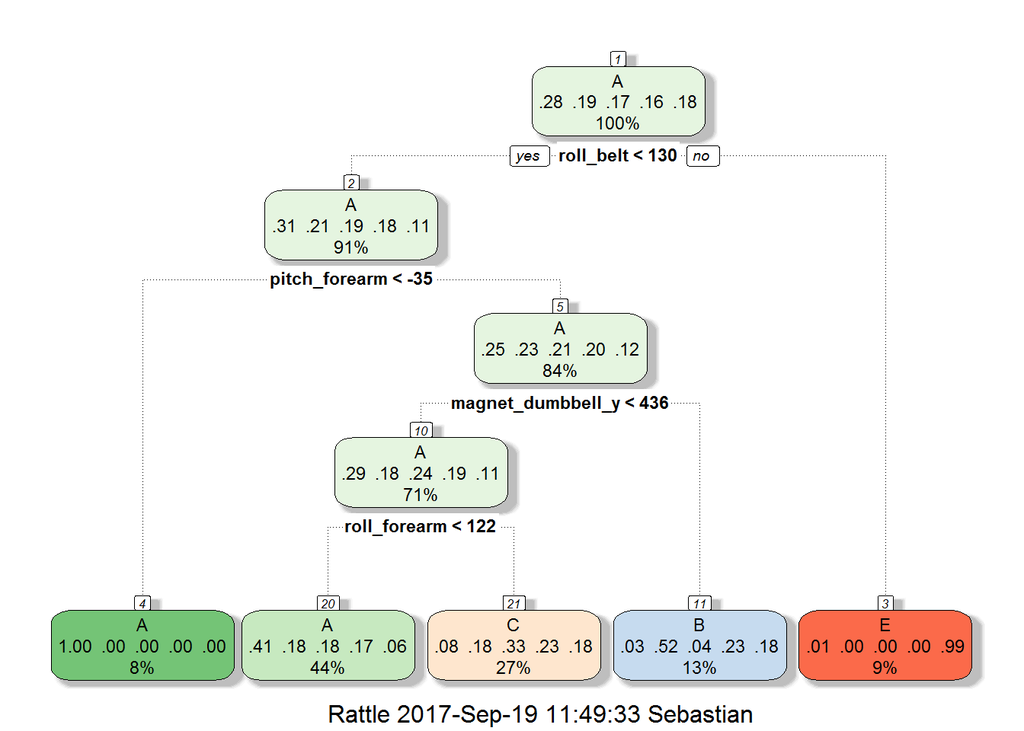

```r
fancyRpartPlot(fit_rpart$finalModel)
```

Predicting results using the valid set

```r
predict_rpart <- predict(fit_rpart, training.valid)
(conf_rpart <- confusionMatrix(training.valid$classe, predict_rpart))
```

```
## Confusion Matrix and Statistics
##
##           Reference
## Prediction    A    B    C    D    E
##          A 2029   44  155    0    4
##          B  638  505  375    0    0
##          C  644   49  675    0    0
##          D  567  232  487    0    0
##          E  209  211  383    0  639
##
## Overall Statistics
##
##                Accuracy : 0.4904
##                  95% CI : (0.4793, 0.5016)
##     No Information Rate : 0.5209
##     P-Value [Acc > NIR] : 1
##
##                   Kappa : 0.3339
##  Mcnemar's Test P-Value : NA
##
## Statistics by Class:
##
##                      Class: A Class: B Class: C Class: D Class: E
## Sensitivity            0.4965  0.48511  0.32530       NA  0.99378
## Specificity            0.9460  0.85114  0.87992   0.8361  0.88852
## Pos Pred Value         0.9091  0.33267  0.49342       NA  0.44313
## Neg Pred Value         0.6334  0.91530  0.78388       NA  0.99938
## Prevalence             0.5209  0.13268  0.26447   0.0000  0.08195
## Detection Rate         0.2586  0.06436  0.08603   0.0000  0.08144
## Detection Prevalence   0.2845  0.19347  0.17436   0.1639  0.18379
## Balanced Accuracy      0.7212  0.66812  0.60261       NA  0.94115
```

```r
(accuracy_rpart <- conf_rpart$overall[1])
```

```
## Accuracy
## 0.490441
```

Using classification tree does not predict the outcome classe

# Random Forest

Therefore, I will use random forest. Thanks to [kaggle forum post](https://www.kaggle.com/general/7951) because the original take a lot of time to process in my pc.

```r
library(randomForest)
mtry <- tuneRF(training.train[,-53], training.train$classe, ntreeTry=500, stepFactor=1.5,improve=0.01,
               plot=FALSE, trace=TRUE, dobest=FALSE)
```

[output not shown]

```r
fit_rt <- randomForest(classe~., data=training.train, mtry=9, ntree=500)
```

Predicting the outcomes using a valid set

```r
predict_rf <- predict(fit_rt, training.valid)
conf_rf <- confusionMatrix(training.valid$classe, predict_rf)
conf_rf
```

```
## Confusion Matrix and Statistics
##
##           Reference
## Prediction    A    B    C    D    E
##          A 2231    0    0    1    0
##          B   10 1503    5    0    0
##          C    0   13 1350    5    0
##          D    0    0   20 1264    2
##          E    0    0    2    2 1438
##
## Overall Statistics
##
##                Accuracy : 0.9924
##                  95% CI : (0.9902, 0.9942)
##     No Information Rate : 0.2856
##     P-Value [Acc > NIR] : < 2.2e-16
##
##                   Kappa : 0.9903
##  Mcnemar's Test P-Value : NA
##
## Statistics by Class:
##
##                      Class: A Class: B Class: C Class: D Class: E
## Sensitivity            0.9955   0.9914   0.9804   0.9937   0.9986
## Specificity            0.9998   0.9976   0.9972   0.9967   0.9994
## Pos Pred Value         0.9996   0.9901   0.9868   0.9829   0.9972
## Neg Pred Value         0.9982   0.9979   0.9958   0.9988   0.9997
## Prevalence             0.2856   0.1932   0.1755   0.1621   0.1835
## Detection Rate         0.2843   0.1916   0.1721   0.1611   0.1833
## Detection Prevalence   0.2845   0.1935   0.1744   0.1639   0.1838
## Balanced Accuracy      0.9977   0.9945   0.9888   0.9952   0.9990
```

```r
accuracy_rf <- conf_rf$overall[1]
accuracy_rf
```

```
##  Accuracy
## 0.9923528
```

Much better!

# Prediction on testing set

I will test the results with the test initial data

```r
(predict(fit_rt, test.cleaned))
```

```
##  1  2  3  4  5  6  7  8  9 10 11 12 13 14 15 16 17 18 19 20
##  B  A  B  A  A  E  D  B  A  A  B  C  B  A  E  E  A  B  B  B
## Levels: A B C D E
```